# Clase estadísticas descriptivas

Lic. Ezequiel Marin

Martes 8 de abril del 2025 | LABPP | FSOC | UBA

# Descripción estadística de los homicidios londinense

## Librerias

Activación y descarga de las librerías de paquetes necesarias para relizar el anàlisis que se aborda en el presente documento.

```r
library(tidyverse) #escencial en R
```

```r
library(lubridate) #es un paquete para poder trabajar con el formato de las fechas
library(ggplot2) # gráficos
```

## Datos

Se descargan datos de homicidios de la policía de londres: https://data.london.gov.uk/dataset/mps-homicide-dashboard-data

**LIMITACIONES DE LOS DATOS**

Fenomeno criminal, dificultad para medirlo.

Due to an internal IT deployment, from 27th February these datasets may be temporarily disrupted. Work is ongoing to rebuild these datasets.

The data used in the MPS Homicide dashboard is available here Homicide dashboard | Metropolitan Police, along with the related data definitions. Please note that, this data set running quarterly behind with quarterly update.

What does it show and how was the content agreed?

In English and Welsh law, Homicide consists of the sum of 4 separate offences:

Murder (Common Law) *

Manslaughter (sec 5 of the Offences Against The Person Act 1861)

Infanticide (Infanticide Act 1938)

Corporate Manslaughter (Corporate Manslaughter and Corporate Homicide Act 2007) these will not show gender for People Proceeded Against.

*Note that since 1996, the ‘Year and a day rule’ has been abolished. Therefore crimes of GBH can be upgraded to murder if the victim dies from their injuries at any point in time past the original offence.

Caveats

Jurisdiction: Not all homicides in London are recorded by the MPS and presented in this report. It should be noted that 2 other police forces have jurisdiction within the boundary of London: The City of London Police (COLP) and British Transport Police (BTP). Therefore any homicides committed within their jurisdiction will be recorded and reported by them, and not the MPS.

Terrorism: The victims of the terrorist attacks in London in 2005 and 2017 are included in this data. However, note that for 2005, the victims of the Tavistock Square bus bombing are in the jurisdiction of the MPS and so included in this report, whereas the victims of the three tube train bombings are in the jurisdiction of the BTP and so do not appear in this report. In addition, note that for the London Bridge attacks of 2017, 1 victim was in the jurisdiction of the COLP and so is not in this report, whereas the rest of the victims were in the jurisdiction of the MPS and so are in this report.

y carga

```r
homicidiosLON <- read.csv("data/Homicide Proceeded 2003 - March 2024.csv",
                        sep=",",
                        encoding = "UTF-8",
                        stringsAsFactors = TRUE)

dim(homicidiosLON)
```

```
## [1] 4512    8
```

Entre el año 2003 y marzo del 2024, la policía metropolitana de londres registró **4.512** procedimientos judiciales de homicidios en su jurisdicción. Estos son operacionalizados en ocho variables. A continuación se ven cuáles son:

```r
names(homicidiosLON)
```

```
## [1] "Count.of.PPA"              "Borough"
## [3] "Gender"                    "Age.Group"
## [5] "Self.Classified.Ethnicity" "Offence.Type"
## [7] "Charged.Summonsed"         "Proceedings.Date"
```

Count.of.PPA : siempre 1 Borough : ciudad Gender : género Age.Group : rango etareo Self.Classified.Ethnicity : etnia autopercibida Offence.Type: tipo de ofensa Charged.Summonsed : Proceedings.Date : fecha del acta

```r
homicidiosLON_13_23 <- homicidiosLON %>%
  mutate(Prom.Edad = case_when(Age.Group == "10 to 14" ~ 12,
                               Age.Group == "15 to 19" ~ 17,
                               Age.Group == "20 to 24" ~ 22,
                               Age.Group == "25 to 29" ~ 27,
                               Age.Group == "30 to 34" ~ 32,
                               Age.Group == "35 to 39" ~ 37,
                               Age.Group == "40 to 44" ~ 42,
                               Age.Group == "45 to 49" ~ 47,
                               Age.Group == "50 to 54" ~ 52,
                               Age.Group == "55 to 59" ~ 57,
                               Age.Group == "60 to 64" ~ 62,
                               Age.Group == "65 and over" ~ 67,),
         Genero = case_when(Gender == "Female" ~ 0,
                            Gender == "Male" ~ 1)) %>%
   mutate(Proceedings.Date = my(Proceedings.Date),
          Mes = month(Proceedings.Date),
          Anio = year(Proceedings.Date)) %>%
  mutate(Mes = as.factor(Mes)) %>%
  filter(Anio > 2012 & Anio < 2024)

dim(homicidiosLON_13_23)
```

```
## [1] 2183   12
```

De 8 variables originales agregamos 4 más:

Prom.Edad Género Mes Ano

## Análisis

Medidas de tendencia central

```r
summary(homicidiosLON_13_23)
```

```
##   Count.of.PPA      Borough            Gender        Age.Group
##  Min.   :1     Brent    : 125   Female    : 141   15 to 19:675
##  1st Qu.:1     Haringey : 124   Male      :2038   20 to 24:493
##  Median :1     Greenwich: 119   Unrecorded:   4   25 to 29:305
##  Mean   :1     Newham   : 119                     30 to 34:210
##  3rd Qu.:1     Enfield  : 100                     35 to 39:153
##  Max.   :1     Croydon  :  97                     40 to 44:106
##                (Other)  :1499                     (Other) :241
##                        Self.Classified.Ethnicity                 Offence.Type
##  Asian                              : 207        Corporate Manslaughter:  10
##  Black                              :1003        Infanticide           :   0
##  Mixed                              : 119        Manslaughter          :  96
##  Other                              :  85        Murder                :2077
##  Person declines to define ethnicity: 128
##  SCE Not Recorded                   :  38
##  White                              : 603
##            Charged.Summonsed Proceedings.Date       Prom.Edad
##  Accused is Deceased:  23    Min.   :2013-01-01   Min.   :12.00
##  Charge or Summons  :2160    1st Qu.:2015-11-01   1st Qu.:17.00
##  Recording Error    :   0    Median :2018-12-01   Median :22.00
##                              Mean   :2018-09-06   Mean   :27.03
##                              3rd Qu.:2021-04-01   3rd Qu.:32.00
##                              Max.   :2023-12-01   Max.   :67.00
##
##      Genero            Mes           Anio
##  Min.   :0.0000   3      :227   Min.   :2013
##  1st Qu.:1.0000   11     :224   1st Qu.:2015
##  Median :1.0000   6      :202   Median :2018
##  Mean   :0.9353   1      :188   Mean   :2018
##  3rd Qu.:1.0000   9      :181   3rd Qu.:2021
##  Max.   :1.0000   7      :177   Max.   :2023
##  NA's   :4        (Other):984
```

Histograma género

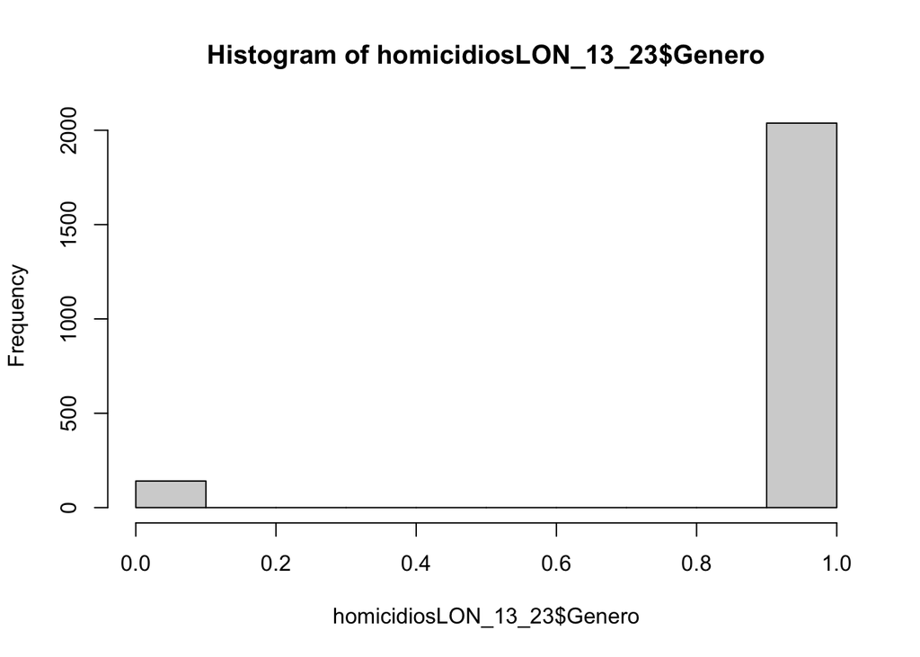

```r
hist(homicidiosLON_13_23$Genero)
```

Histograma con la edad

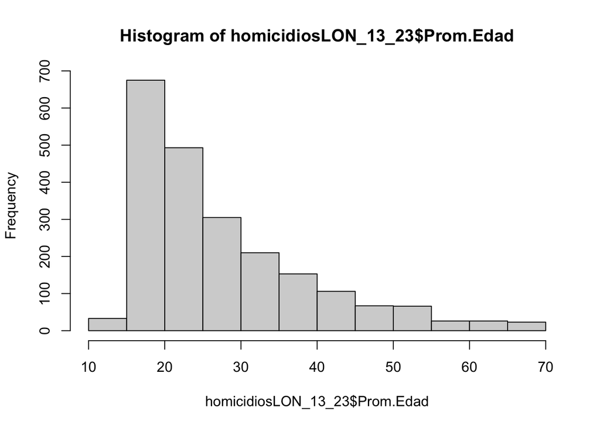

```r
hist(homicidiosLON_13_23$Prom.Edad)
```

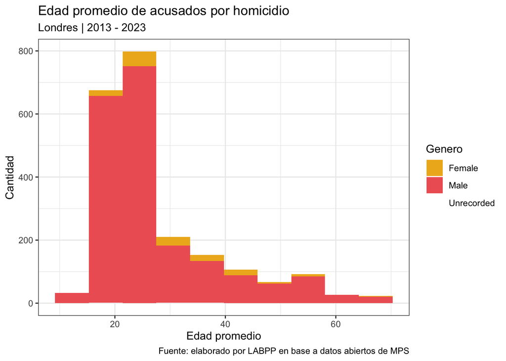

```r
ggplot(homicidiosLON_13_23)+
  geom_histogram( aes(x = Prom.Edad, fill = Gender), bins = 10)+
  labs(title="Edad promedio de acusados por homicidio",
       subtitle = "Londres | 2013 - 2023",
       fill="Genero",
       x="Edad promedio",
       y="Cantidad",
       caption="Fuente: elaborado por LABPP en base a datos abiertos de MPS")+
  scale_fill_manual(values = c("goldenrod2", "indianred2", "white"))+
  theme_bw()
```

Cantidad de homicidios por distrito

```r
homicidios_por_distrito <- homicidiosLON_13_23 %>%
  group_by(Borough, Anio) %>%
  summarise(Homicidios = n()) %>%
  arrange(desc(Homicidios))
summary(homicidios_por_distrito)
```

```
##                Borough         Anio        Homicidios
##  Barking & Dagenham: 11   Min.   :2013   Min.   : 1.000
##  Barnet            : 11   1st Qu.:2015   1st Qu.: 3.000
##  Brent             : 11   Median :2018   Median : 6.000
##  Camden            : 11   Mean   :2018   Mean   : 6.865
##  Ealing            : 11   3rd Qu.:2021   3rd Qu.:10.000
##  Enfield           : 11   Max.   :2023   Max.   :28.000
##  (Other)           :252
```

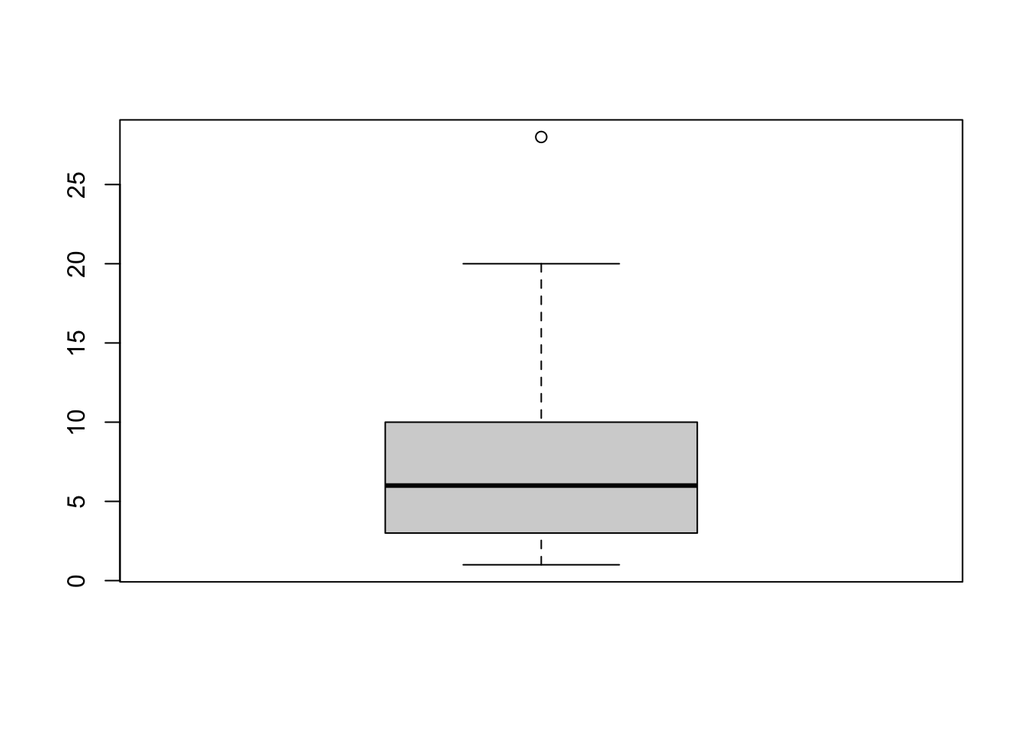

```r
boxplot(homicidios_por_distrito$Homicidios)
```

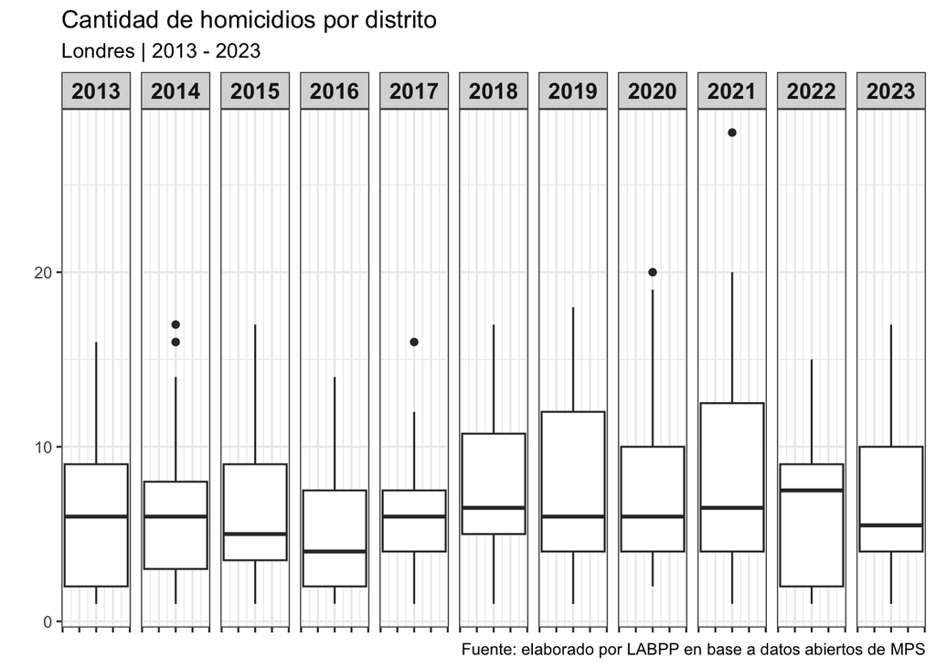

```r
ggplot(homicidios_por_distrito) +
  geom_boxplot(aes(x = Homicidios)) +
  scale_fill_brewer()+
  labs(title = "Cantidad de homicidios por distrito",
       subtitle = "Londres | 2013 - 2023",
       x = "",
       fill = "",
       caption = "Fuente: elaborado por LABPP en base a datos abiertos de MPS") +
  theme_bw() +
  facet_grid(~Anio)+ # Vamos a ordenar los resultados por día.
  coord_flip() + # vamos a rotar nuestr gráfico.
  theme(axis.text.x = element_blank(),  # Vamos a quitar el texto de nuestro eje y.
        strip.text = element_text(face = "bold", size = 12)) # Vamos a sombrear los títulos nuestros encabezados.
```

Frecuencias con género

Tasa de imputación Variable original: Charged.Summonsed Idea: Codificar como 1 (sí fue imputado) y 0 (no) Esto permite calcular proporciones, medias y estudiar correlaciones con otras variables como género, etnia, etc.

Histograma de edades • Promedio y desviación estándar • Comparaciones por género o etnia

¿En qué años ocurrieron más homicidios? • ¿Hay estacionalidad en los homicidios?

Histograma

Boxplot